# 6.3 Geographical Visualizations with Python

### Will Viruet

#### This script contains the following from Task

#### 3. Import the libraries you need for your analysis (e.g., folium).

#### 4. Find a JSON/GeoJSONfile containing location data that corresponds to the location data in your student project data (or use this one if your analysis is about the US). We’ve listed a few suggestions to get you started:

#### Datahub—country polygons as GeoJSON;

#### GEO JSON—customisable JSON files for different continents or the entire globe;

#### Kaggle—world countries JSON;

#### GitHub—annotated GeoJSON geometry files for the world.

#### 5. Wrangle your project data to meet the needs of your analysis.

#### 6. Clean your data set—watch for missing and extreme values.

#### 7. Create a choropleth map using a variable of your choice.

#### 8. Discuss the results and what they mean in a markdown section.

#### Does the analysis answer any of your existing research questions?

#### Does the analysis lead you to any new research questions?

### 3. Import the libraries you need for your analysis (e.g., folium).

```python
import pandas as pd
import numpy as np
import seaborn as sns
import matplotlib
import os
import folium
import json
pip install geopandas
```

```python
file_path = r'C:\Users\virue\OneDrive\Desktop\Will CareerFoundry\Achievement 6\UFC Data Set\data.csv'
```

```python
df = pd.read_csv(file_path)
```

```python
df.head()
```

|  | R_fighter | B_fighter | Referee | date | location | Winner | title_bout | weight_class | B_avg_KD | B_avg_opp_KD | ... | R_win_by_Decision_Unanimous | R_win_by_KO/TKO | R_win_by_Submission | R_win_by_TKO_Doctor_Stoppage | R_Stance | R_Height_cms | R_Reach_cms | R_Weight_lbs | B_age | R_age |
| --- | --- | --- | --- | --- | --- | --- | --- | --- | --- | --- | --- | --- | --- | --- | --- | --- | --- | --- | --- | --- | --- |
| 0 | Adrian Yanez | Gustavo Lopez | Chris Tognoni | 2021-03-20 | Las Vegas, Nevada, USA | Red | False | Bantamweight | 0.000 | 0.0 | ... | 0 | 1 | 0 | 0 | Orthodox | 170.18 | 177.80 | 135.0 | 31.0 | 27.0 |
| 1 | Trevin Giles | Roman Dolidze | Herb Dean | 2021-03-20 | Las Vegas, Nevada, USA | Red | False | Middleweight | 0.500 | 0.0 | ... | 0 | 3 | 0 | 0 | Orthodox | 182.88 | 187.96 | 185.0 | 32.0 | 28.0 |
| 2 | Tai Tuivasa | Harry Hunsucker | Herb Dean | 2021-03-20 | Las Vegas, Nevada, USA | Red | False | Heavyweight | NaN | NaN | ... | 1 | 3 | 0 | 0 | Southpaw | 187.96 | 190.50 | 264.0 | 32.0 | 28.0 |
| 3 | Cheyanne Buys | Montserrat Conejo | Mark Smith | 2021-03-20 | Las Vegas, Nevada, USA | Blue | False | WomenStrawweight | NaN | NaN | ... | 0 | 0 | 0 | 0 | Switch | 160.02 | 160.02 | 115.0 | 28.0 | 25.0 |
| 4 | Marion Reneau | Macy Chiasson | Mark Smith | 2021-03-20 | Las Vegas, Nevada, USA | Blue | False | WomenBantamweight | 0.125 | 0.0 | ... | 1 | 2 | 2 | 0 | Orthodox | 167.64 | 172.72 | 135.0 | 29.0 | 43.0 |

5 rows × 144 columns

```python
df.shape
```

```
(6012, 144)
```

### 4. Find a JSON/GeoJSONfile containing location data that corresponds to the location data in your student project data (or use this one if your analysis is about the US). We’ve listed a few suggestions to get you started:

```python
import pandas as pd

# Read the JSON file
country_geo = pd.read_json(r'C:\Users\virue\OneDrive\Desktop\Will CareerFoundry\Achievement 6\6.3\world-countries.json')

# Display the first few rows to verify the data
print(country_geo.head())
```

```
                type                                           features
0  FeatureCollection  {'type': 'Feature', 'properties': {'name': 'Af...
1  FeatureCollection  {'type': 'Feature', 'properties': {'name': 'An...
2  FeatureCollection  {'type': 'Feature', 'properties': {'name': 'Al...
3  FeatureCollection  {'type': 'Feature', 'properties': {'name': 'Un...
4  FeatureCollection  {'type': 'Feature', 'properties': {'name': 'Ar...
```

### Check to see if there are any locations outside the United States. Yes there is.

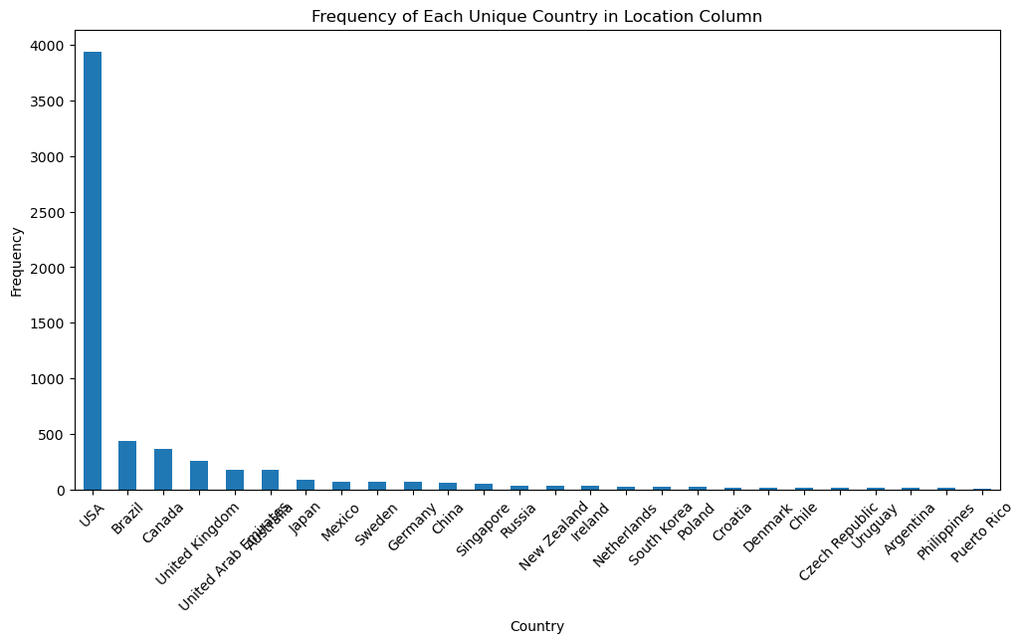

```python
import matplotlib.pyplot as plt

# Extracting country names from the 'location' column
df['country'] = df['location'].apply(lambda x: x.split(',')[-1].strip())

# Counting the frequency of each unique country
country_counts = df['country'].value_counts()

# Plotting the bar chart
plt.figure(figsize=(12, 6))
country_counts.plot(kind='bar')
plt.title('Frequency of Each Unique Country in Location Column')
plt.xlabel('Country')
plt.ylabel('Frequency')
plt.xticks(rotation=45)
plt.show()
```

### 5. Wrangle your project data to meet the needs of your analysis.

```python
# Extracting unique country names
unique_countries = df['location'].unique()

# Displaying the list of unique countries
print("List of countries where UFC fights have taken place:")
for country in unique_countries:
    print(country)
```

```
List of countries where UFC fights have taken place:
Las Vegas, Nevada, USA
Abu Dhabi, Abu Dhabi, United Arab Emirates
Jacksonville, Florida, USA
Brasilia, Distrito Federal, Brazil
Norfolk, Virginia, USA
Auckland, New Zealand
Rio Rancho, New Mexico, USA
Houston, Texas, USA
Raleigh, North Carolina, USA
Busan, South Korea
Washington, DC, USA
Sao Paulo, Sao Paulo, Brazil
Moscow, Moscow, Russia
New York City, New York, USA
Kallang, Singapore
Boston, Massachusetts, USA
Tampa, Florida, USA
Melbourne, Victoria, Australia
Copenhagen, Denmark
Mexico City, Distrito Federal, Mexico
Vancouver, British Columbia, Canada
Shenzhen, Guangdong, China
Anaheim, California, USA
Montevideo, Uruguay
Newark, New Jersey, USA
Edmonton, Alberta, Canada
San Antonio, Texas, USA
Sacramento, California, USA
Minneapolis, Minnesota, USA
Greenville, South Carolina, USA
Chicago, Illinois, USA
Stockholm, Sweden
Rochester, New York, USA
Rio de Janeiro, Rio de Janeiro, Brazil
Ottawa, Ontario, Canada
Sunrise, Florida, USA
Saint Petersburg, Saint Petersburg, Russia
Atlanta, Georgia, USA
Philadelphia, Pennsylvania, USA
```

[output cut: 112 more lines]

```
Uncasville, Connecticut, USA
Miami, Florida, USA
Bossier City, Louisiana, USA
Tokyo, Japan
Cedar Rapids, Iowa, USA
Lake Charles, Louisiana, USA
Chiba, Japan
Birmingham, Alabama, USA
Bay St. Louis, Mississippi, USA
Mobile, Alabama, USA
Yokohama, Kanagawa, Japan
Augusta, Georgia, USA
Dothan, Alabama, USA
San Juan, Puerto Rico
Casper, Wyoming, USA
```

```python
# Extracting country names from the 'location' column
df['country'] = df['location'].apply(lambda x: x.split(',')[-1].strip())

# Displaying the list of unique countries
unique_countries = df['country'].unique()

# Displaying the list of unique countries
print("List of unique countries extracted from the 'location' column:")
for country in unique_countries:
    print(country)

# Now you need to match these country names with the country names in your GeoJSON file
# Ensure that the country names in your GeoJSON file match the ones extracted from the 'location' column
```

```
List of unique countries extracted from the 'location' column:
USA
United Arab Emirates
Brazil
New Zealand
South Korea
Russia
Singapore
Australia
Denmark
Mexico
Canada
China
Uruguay
Sweden
United Kingdom
Czech Republic
Argentina
Germany
Chile
Poland
Japan
Netherlands
Croatia
Ireland
Philippines
Puerto Rico
```

```python
# Select only the necessary columns and put them in a list called columns

columns = ['USA',
'United Arab Emirates',
'Brazil',
'New Zealand',
'South Korea',
'Russia',
'Singapore',
'Australia',
'Denmark',
'Mexico',
'Canada',
'China',
'Uruguay',
'Sweden',
'United Kingdom',
'Czech Republic',
'Argentina',
'Germany',
'Chile',
'Poland',
'Japan',
'Netherlands',
'Croatia',
'Ireland',
'Philippines',
'Puerto Rico']
```

```python
# Define a mapping dictionary to match country names with GeoJSON country names
country_mapping = {
    'USA': 'United States',
    'Brazil': 'Brazil',
    'Canada': 'Canada',
    'United Arab Emirates': 'United Arab Emirates',
    'South Korea': 'South Korea',
    'New Zealand': 'New Zealand',
    'Russia': 'Russia',
    'Singapore': 'Singapore',
    'Australia': 'Australia',
    'Denmark': 'Denmark',
    'Mexico': 'Mexico',
    'China': 'China',
    'Uruguay': 'Uruguay',
    'Sweden': 'Sweden',
    'Chile': 'Chile',
    'United Kingdom': 'United Kingdom',
    'Czech Republic': 'Czech Republic',
    'Argentina': 'Argentina',
    'Poland': 'Poland',
    'Japan': 'Japan',
    'Netherlands': 'Netherlands',
    'Scotland': 'Scotland',
    'Philippines': 'Philippines',
    'Germany': 'Germany',
    'Ireland': 'Ireland',
    'Northern Ireland': 'United Kingdom',
    'Croatia': 'Croatia',
    'South Africa': 'South Africa',
    'France': 'France',
    'Italy': 'Italy',
    'Austria': 'Austria',
    'Finland': 'Finland',
    'Norway': 'Norway',
    'Spain': 'Spain',
    'Turkey': 'Turkey',
    'Portugal': 'Portugal',
    'Belgium': 'Belgium',
    'Switzerland': 'Switzerland',
    'Hungary': 'Hungary',
    'Ukraine': 'Ukraine',
    'Greece': 'Greece',
    'Israel': 'Israel',
    'Iceland': 'Iceland',
    'Bulgaria': 'Bulgaria',
    'Serbia': 'Serbia',
    'Lithuania': 'Lithuania',
    'Latvia': 'Latvia',
    'Estonia': 'Estonia',
    'Romania': 'Romania',
    'Slovakia': 'Slovakia',
    'Slovenia': 'Slovenia',
    'Luxembourg': 'Luxembourg',
    'Cyprus': 'Cyprus',
    'Malta': 'Malta',
    'Bahrain': 'Bahrain',
    'Qatar': 'Qatar',
    'Kuwait': 'Kuwait',
    'Oman': 'Oman',
    'Saudi Arabia': 'Saudi Arabia',
    'Bolivia': 'Bolivia',
    'Colombia': 'Colombia',
    'Ecuador': 'Ecuador',
    'Paraguay': 'Paraguay',
    'Peru': 'Peru',
    'Venezuela': 'Venezuela',
    'Costa Rica': 'Costa Rica',
    'Honduras': 'Honduras',
    'Nicaragua': 'Nicaragua',
    'Panama': 'Panama',
    'Jamaica': 'Jamaica',
    'Bahamas': 'Bahamas',
    'Belize': 'Belize',
    'Guyana': 'Guyana',
    'Suriname': 'Suriname',
    'Trinidad and Tobago': 'Trinidad and Tobago',
    'Barbados': 'Barbados',
    'Antigua and Barbuda': 'Antigua and Barbuda',
    'Saint Kitts and Nevis': 'Saint Kitts and Nevis',
    'Saint Lucia': 'Saint Lucia',
    'Saint Vincent and the Grenadines': 'Saint Vincent and the Grenadines',
    'Grenada': 'Grenada',
    'Dominica': 'Dominica',
    'Saint Martin': 'France',
    'Guadeloupe': 'France',
    'Martinique': 'France',
    'Saint Barthelemy': 'France',
    'Saint Pierre and Miquelon': 'France',
    'Aruba': 'Netherlands',
    'Curacao': 'Netherlands',
    'Sint Maarten': 'Netherlands',
    'Bonaire': 'Netherlands',
    'Saba': 'Netherlands',
    'Sint Eustatius': 'Netherlands',
    'Cayman Islands': 'Cayman Islands',
    'Turks and Caicos Islands': 'United Kingdom',
    'British Virgin Islands': 'United Kingdom',
    'Anguilla': 'United Kingdom',
    'Montserrat': 'United Kingdom',
    'Gibraltar': 'United Kingdom',
    'Saint Helena, Ascension, and Tristan da Cunha': 'United Kingdom',
    'Falkland Islands': 'United Kingdom',
    'Niue': 'Niue',
    'Tokelau': 'New Zealand',
    'Cook Islands': 'New Zealand',
    'Pitcairn Islands': 'United Kingdom',
    'Marshall Islands': 'Marshall Islands',
    'Micronesia': 'Micronesia',
    'Palau': 'Palau',
    'Nauru': 'Nauru',
    'Tuvalu': 'Tuvalu',
    'Kiribati': 'Kiribati',
    'Vanuatu': 'Vanuatu',
    'Solomon Islands': 'Solomon Islands',
    'Samoa': 'Samoa',
    'Tonga': 'Tonga',
    'Fiji': 'Fiji',
    'Papua New Guinea': 'Papua New Guinea',
    'New Caledonia': 'New Caledonia',
    'French Polynesia': 'France',
    'Wallis and Futuna': 'France',
    'American Samoa': 'American Samoa',
    'Guam': 'Guam',
    'Northern Mariana Islands': 'Northern Mariana Islands',
}

# Match country names in the UFC dataset with names in the mapping
df['matched_country'] = df['country'].map(country_mapping)

# Check for any unmatched country names
unmatched_countries = df[df['matched_country'].isnull()]['country'].unique()
print("Unmatched country names:", unmatched_countries)
```

```
Unmatched country names: ['Puerto Rico']
```

```python
# Manually map 'Puerto Rico' to 'United States'
df.loc[df['country'] == 'Puerto Rico', 'matched_country'] = 'United States'
```

#### 6. Clean your data set—watch for missing and extreme values.

```python
#Check for Missing Values
missing_values = df.isnull().sum()
print("Missing Values:")
print(missing_values)
```

```
Missing Values:
R_fighter            0
B_fighter            0
Referee             32
date                 0
location             0
                  ...
R_Weight_lbs         2
B_age              172
R_age               63
country              0
matched_country      0
Length: 146, dtype: int64
```

```python
# Calculate the median value of 'R_Weight_lbs'
median_R_Weight_lbs = df['R_Weight_lbs'].median()

# Impute missing values with the median
df['R_Weight_lbs'].fillna(median_R_Weight_lbs, inplace=True)
```

#### Duplicates Check

```python
# Check for duplicates
dups = df.duplicated()

# Display the shape to see if there are duplicates
print("Shape of duplicates array:", dups.shape)

# Print the duplicates
print("Duplicates:", dups)
```

```
Shape of duplicates array: (6012,)
Duplicates: 0       False
1       False
2       False
3       False
4       False
        ...
6007    False
6008    False
6009    False
6010    False
6011    False
Length: 6012, dtype: bool
```

##### Extreme values checks

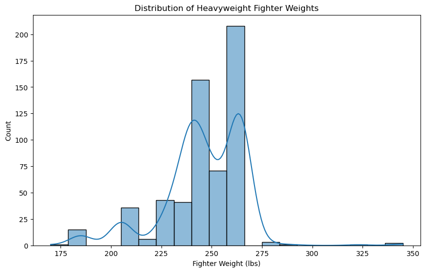

```python
# Filter DataFrame to include only heavyweight fighters
heavyweight_df = df[df['weight_class'] == 'Heavyweight']

# Show extreme values for 'R_Weight_lbs' in the heavyweight category
plt.figure(figsize=(10, 6))
sns.histplot(heavyweight_df['R_Weight_lbs'], bins=20, kde=True)
plt.title('Distribution of Heavyweight Fighter Weights')
plt.xlabel('Fighter Weight (lbs)')
plt.ylabel('Count')
plt.show()
```

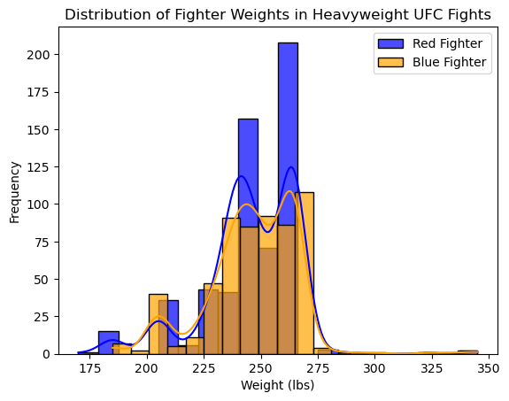

```python
# Filter the DataFrame to include only heavyweight fights
heavyweight_data = df[df['weight_class'] == 'Heavyweight']

# Check the distribution of the weight variable for heavyweight fighters
sns.histplot(heavyweight_data['R_Weight_lbs'], bins=20, kde=True, color='blue', alpha=0.7, label='Red Fighter')
sns.histplot(heavyweight_data['B_Weight_lbs'], bins=20, kde=True, color='orange', alpha=0.7, label='Blue Fighter')
plt.title('Distribution of Fighter Weights in Heavyweight UFC Fights')
plt.xlabel('Weight (lbs)')
plt.ylabel('Frequency')
plt.legend()
plt.show()
```

#### 7. Create a choropleth map using a variable of your choice.

```python
import geopandas as gpd
import matplotlib.pyplot as plt

# Load a world map shapefile
world = gpd.read_file(gpd.datasets.get_path('naturalearth_lowres'))

# Assuming your data is in a DataFrame called 'df' with columns 'matched_country', 'R_Height_cms', and 'B_Height_cms'
# Merge your data with the geographic data
merged_data = world.merge(df[['matched_country', 'R_Height_cms', 'B_Height_cms']], how='left', left_on='name', right_on='matched_country')
```

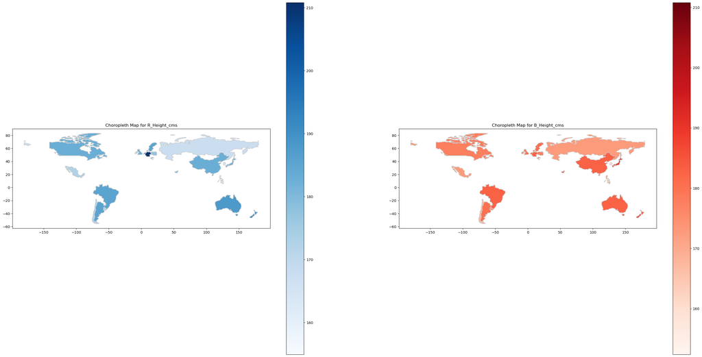

```python
# Plot the choropleth map for R_Height_cms
fig, ax = plt.subplots(1, 2, figsize=(36, 18))  # Make the figure size even bigger

# Plot for R_Height_cms
merged_data.plot(column='R_Height_cms', cmap='Blues', linewidth=0.8, ax=ax[0], edgecolor='0.8', legend=True)
ax[0].set_title('Choropleth Map for R_Height_cms')

# Plot for B_Height_cms
merged_data.plot(column='B_Height_cms', cmap='Reds', linewidth=0.8, ax=ax[1], edgecolor='0.8', legend=True)
ax[1].set_title('Choropleth Map for B_Height_cms')

plt.show()
```

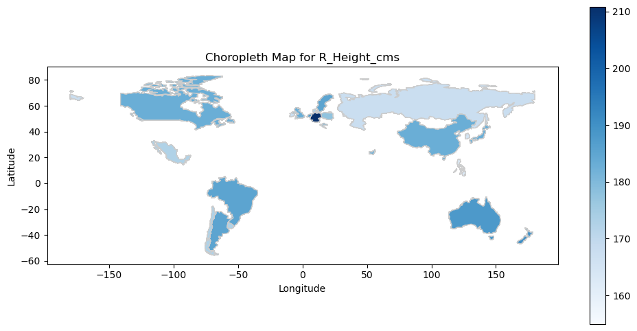

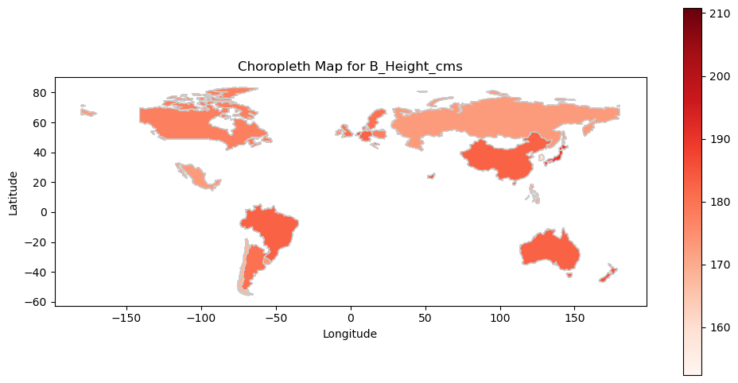

```python
# Plot for R_Height_cms
fig, ax = plt.subplots(figsize=(12, 6))
merged_data.plot(column='R_Height_cms', cmap='Blues', linewidth=0.8, ax=ax, edgecolor='0.8', legend=True)
ax.set_title('Choropleth Map for R_Height_cms')
ax.set_xlabel('Longitude')
ax.set_ylabel('Latitude')
# Save the plot
plt.savefig(r'C:\Users\virue\OneDrive\Desktop\Will CareerFoundry\Achievement 6\6.3\choropleth\R_Height_cms_map.png')

# Plot for B_Height_cms
fig, ax = plt.subplots(figsize=(12, 6))
merged_data.plot(column='B_Height_cms', cmap='Reds', linewidth=0.8, ax=ax, edgecolor='0.8', legend=True)
ax.set_title('Choropleth Map for B_Height_cms')
ax.set_xlabel('Longitude')
ax.set_ylabel('Latitude')
# Save the plot
plt.savefig(r'C:\Users\virue\OneDrive\Desktop\Will CareerFoundry\Achievement 6\6.3\choropleth\B_Height_cms_map.png')
```

#### Analyzing the geographical differences in fighter heights can influence competition results, training methods, and talent identification.

#### I have started analyzing UFC fight data to uncover what makes fighters successful, considering win-loss records, weight class, and other factors. Further analysis comparing these factors among fighters with high win rates is needed. This will help draw conclusions about the characteristics or strategies linked to the highest win rates in UFC history.